# Regression Airbnb

```python
# Packages
import numpy as np
from scipy import stats
import pandas as pd
import matplotlib.pyplot as plt
import seaborn as sns
import xgboost as xgb
import warnings

# Model selection and evaluation tools
from sklearn.model_selection import train_test_split
from sklearn.model_selection import RandomizedSearchCV
from sklearn.metrics import mean_squared_error, r2_score
from sklearn.preprocessing import MinMaxScaler
from sklearn.preprocessing import StandardScaler
from sklearn.linear_model import RidgeCV
import pandas as pd, numpy as np, matplotlib.pyplot as plt, time
%matplotlib inline
```

```python
# Plot settings
sns.set_context('notebook')
sns.set_style('ticks')
colours = ['#1F77B4', '#FF7F0E', '#2CA02C', '#DB2728', '#9467BD', '#8C564B', '#E377C2','#7F7F7F', '#BCBD22', '#17BECF']
crayon = ['#4E79A7','#F28E2C','#E15759','#76B7B2','#59A14F', '#EDC949','#AF7AA1','#FF9DA7','#9C755F','#BAB0AB']
sns.set_palette(colours)
%matplotlib inline
plt.rcParams['figure.figsize'] = (9, 6)
```

# Data

```python
# Load data
df=pd.read_csv('train.csv', index_col='Id')
df_test=pd.read_csv('test_modified.csv', index_col='Id') # the reason for loading this file will be explained in "Data Cleaning and Imupation" part
```

```python
### due to too many property_type will chane the property type to 4 category
### Apartment, House, Townhouse, others, these change were not made will introduce training data and test data not having same shape
df['property_type'][df['property_type'].isin(['House','Apartment','Townhouse'])==False] = "Others"

df_test['property_type'][df_test['property_type'].isin(['House','Apartment','Townhouse'])==False] = "Others"
```

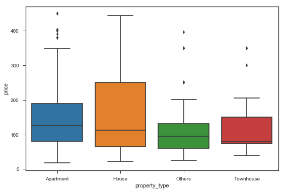

```python
 sns.boxplot(df['property_type'], df['price'])
```

```python
## get predictor X and response y
y =df['price']
X =df.loc[:,df.columns !='price']
```

```python
X_with_dummy=pd.get_dummies(X)
```

```python
X_test_with_dummy=pd.get_dummies(df_test)
```

```python
X_test_with_dummy.shape
```

```
(7967, 39)
```

```python
# test set same structure
list(X_with_dummy.columns.values) == list(X_test_with_dummy.columns.values)
```

```
True
```

```python
X_with_dummy.head(3)
```

| Id | host_total_listings_count | latitude | longitude | accommodates | bathrooms | bedrooms | beds | security_deposit | cleaning_fee | extra_people | ... | room_type_Entire home/apt | room_type_Private room | room_type_Shared room | instant_bookable_f | instant_bookable_t | is_business_travel_ready_f | is_business_travel_ready_t | cancellation_policy_flexible | cancellation_policy_moderate | cancellation_policy_strict |
| --- | --- | --- | --- | --- | --- | --- | --- | --- | --- | --- | --- | --- | --- | --- | --- | --- | --- | --- | --- | --- | --- |
| 0 | 22.0 | -33.846469 | 151.205171 | 2 | 1.0 | 1 | 1.0 | 500.0 | 330.0 | 0 | ... | 1 | 0 | 0 | 1 | 0 | 1 | 0 | 0 | 0 | 1 |
| 1 | 1.0 | -33.895736 | 151.173529 | 2 | 1.5 | 1 | 1.0 | NaN | NaN | 0 | ... | 0 | 1 | 0 | 1 | 0 | 1 | 0 | 1 | 0 | 0 |
| 2 | 1.0 | -33.879322 | 151.222408 | 4 | 2.0 | 2 | 2.0 | 500.0 | 180.0 | 0 | ... | 1 | 0 | 0 | 1 | 0 | 1 | 0 | 0 | 1 | 0 |

3 rows × 39 columns

### Data Cleaning and Imupation

##### Firstly let's see how healthy our data are, anymissing value and what is their percentage

```python
#checking missing value in training dataset
df.isnull().sum()
display((df.isnull().sum()/len(df)*100).sort_values())
```

```
price                           0.0
is_business_travel_ready        0.0
instant_bookable                0.0
number_of_reviews               0.0
maximum_nights                  0.0
minimum_nights                  0.0
cancellation_policy             0.0
bedrooms                        0.0
extra_people                    0.0
room_type                       0.0
property_type                   0.0
longitude                       0.0
latitude                        0.0
accommodates                    0.0
beds                            0.2
host_is_superhost               0.2
host_identity_verified          0.2
host_total_listings_count       0.2
bathrooms                       0.3
cleaning_fee                   30.7
reviews_per_month              31.1
review_scores_rating           34.0
review_scores_accuracy         34.2
review_scores_cleanliness      34.2
review_scores_communication    34.3
review_scores_checkin          34.4
review_scores_location         34.4
review_scores_value            34.4
security_deposit               42.6
dtype: float64
```

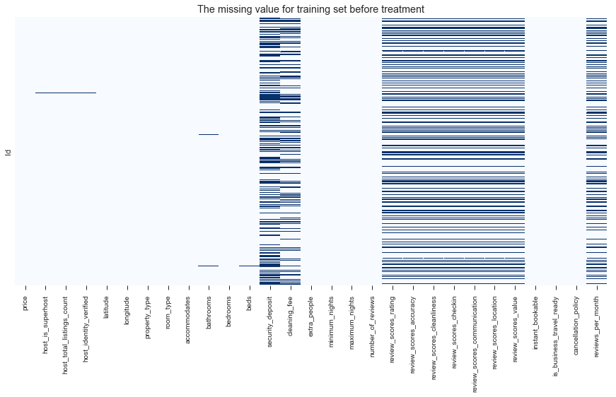

```python
# Visualize missing values in training set before treatment
fig, ax = plt.subplots(figsize=(15,7))
sns.set(font_scale=1.2)
ax.set_title("The missing value for training set before treatment")
sns.heatmap(df.isnull(),yticklabels = False, cbar = False, cmap="Blues")
plt.show()
fig.set_size_inches(18,20)
fig.savefig("Beforetreatment_Training.png")
```

```python
#checking missing value in testing dataset
df_test.isnull().sum()
display((df_test.isnull().sum()/len(df_test)*100).sort_values())
```

```
extra_people                    0.000000
is_business_travel_ready        0.000000
instant_bookable                0.000000
latitude                        0.000000
longitude                       0.000000
property_type                   0.000000
room_type                       0.000000
accommodates                    0.000000
bedrooms                        0.000000
number_of_reviews               0.000000
maximum_nights                  0.000000
cancellation_policy             0.000000
minimum_nights                  0.000000
bathrooms                       0.100414
beds                            0.138070
host_is_superhost               0.150621
host_identity_verified          0.150621
host_total_listings_count       0.150621
reviews_per_month              28.655705
review_scores_rating           30.952680
review_scores_cleanliness      31.128405
review_scores_accuracy         31.178612
review_scores_communication    31.178612
review_scores_checkin          31.304130
review_scores_location         31.304130
review_scores_value            31.341785
cleaning_fee                   31.843856
security_deposit               42.324589
dtype: float64
```

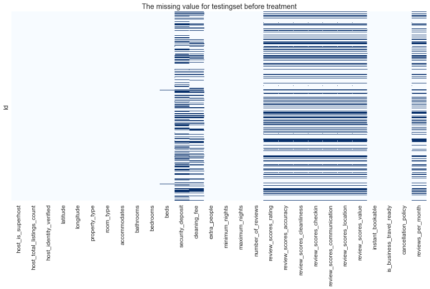

```python
# Visualize missing values in testing set
fig, ax = plt.subplots(figsize=(15,7))
sns.set(font_scale=1.2)
ax.set_title("The missing value for testingset before treatment")
sns.heatmap(df_test.isnull(),yticklabels = False, cbar = False, cmap="Blues")
plt.show()
```

#### The overall dataframe 3 types of data (for both test and training data set)

There is a discrepancy for missing predictors, **bedroom** is missing in test data but no in the training data, so we manually fill the missing data for bedroom in test data so below algorithm can run. The test data is loaded as **"test_modified.csv"**

The list of predictors having missing values to be treated are ['host_is_superhost', 'host_total_listings_count', 'host_identity_verified', 'bathrooms', 'beds', 'security_deposit', 'cleaning_fee', 'review_scores_rating', 'review_scores_accuracy', 'review_scores_cleanliness', 'review_scores_checkin', 'review_scores_communication', 'review_scores_location', 'review_scores_value', 'reviews_per_month']

```python
#####  This function is to update the data frame
# 1.New features created
# 2.Dummy variables created for categorical/binary data
# 3.Missing value being imputed with chosen strategy
#
#################################
def dataframe_treatment(dataframe, STRATEGY = 'median'):
    ## updating datafram
    dataframe['reviewed']=(dataframe['number_of_reviews']>0)
    dataframe['security_deposit_missing'] = dataframe['security_deposit'].isnull()
    dataframe['cleaning_fee_missing']=dataframe['cleaning_fee'].isnull()
    # after created dummy the original categorical variable is gone
    df_with_dummy=pd.get_dummies(dataframe)
    ### features still having nan value
    features_with_missing = df_with_dummy.columns[df_with_dummy.isnull().sum()>0]

    ###impute with input strategy
    from sklearn.preprocessing import Imputer
    imputer = Imputer(strategy=STRATEGY ,verbose = 1)
    values=df_with_dummy[features_with_missing].values
    transfomred_values=imputer.fit_transform(values)
    df_with_dummy[features_with_missing]=transfomred_values

    return df_with_dummy
```

```python
### treating the training dataframe and testing dataframe
### these two dataframe will be used to train our model and making prediction
df_train_treated = dataframe_treatment(df,STRATEGY='mean')
df_test_treated = dataframe_treatment(df_test,STRATEGY='mean')
```

```python
#checking missing value in training dataset
display((df_train_treated.isnull().sum()/len(df)*100).sort_values())
```

```
price                           0.0
security_deposit_missing        0.0
cleaning_fee_missing            0.0
host_is_superhost_f             0.0
host_is_superhost_t             0.0
host_identity_verified_f        0.0
host_identity_verified_t        0.0
property_type_Apartment         0.0
property_type_House             0.0
reviewed                        0.0
property_type_Others            0.0
room_type_Entire home/apt       0.0
room_type_Private room          0.0
room_type_Shared room           0.0
instant_bookable_f              0.0
instant_bookable_t              0.0
is_business_travel_ready_f      0.0
is_business_travel_ready_t      0.0
cancellation_policy_flexible    0.0
property_type_Townhouse         0.0
cancellation_policy_moderate    0.0
reviews_per_month               0.0
review_scores_location          0.0
host_total_listings_count       0.0
latitude                        0.0
longitude                       0.0
accommodates                    0.0
bathrooms                       0.0
bedrooms                        0.0
beds                            0.0
security_deposit                0.0
review_scores_value             0.0
cleaning_fee                    0.0
minimum_nights                  0.0
maximum_nights                  0.0
number_of_reviews               0.0
review_scores_rating            0.0
review_scores_accuracy          0.0
review_scores_cleanliness       0.0
review_scores_checkin           0.0
review_scores_communication     0.0
extra_people                    0.0
cancellation_policy_strict      0.0
dtype: float64
```

```python
df_train_treated.shape
```

```
(1000, 43)
```

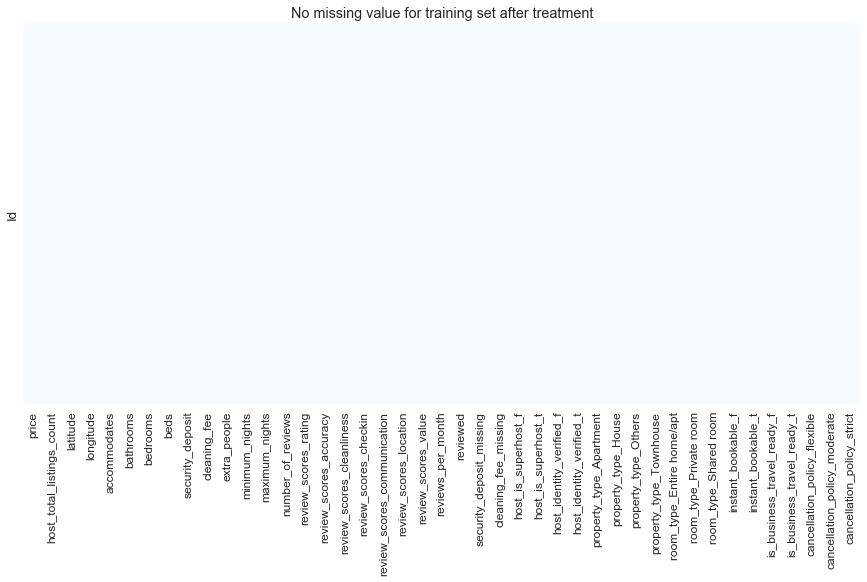

```python
# Visualize NO missing values in training set after treatment
fig, ax = plt.subplots(figsize=(15,7))
sns.set(font_scale=1.2)
ax.set_title("No missing value for training set after treatment")
sns.heatmap(df_train_treated.isnull(),yticklabels = False, cbar = False, cmap="Blues")
plt.show()
fig.set_size_inches(18,20)
fig.savefig("Aftertreatment_Training.png")
```

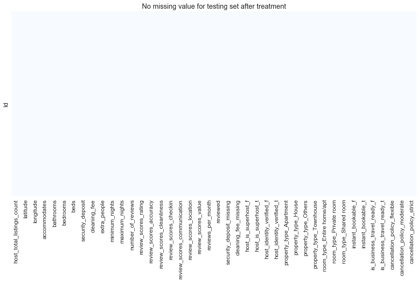

```python
# Visualize NO missing values in testing set after treatment
fig, ax = plt.subplots(figsize=(15,7))
sns.set(font_scale=1.2)
ax.set_title("No missing value for testing set after treatment")
sns.heatmap(df_test_treated.isnull(),yticklabels = False, cbar = False, cmap="Blues")
plt.show()
```

```python
df_test_treated.info()
```

```
<class 'pandas.core.frame.DataFrame'>
Int64Index: 7967 entries, 0 to 7966
Data columns (total 42 columns):
host_total_listings_count       7967 non-null float64
latitude                        7967 non-null float64
longitude                       7967 non-null float64
accommodates                    7967 non-null int64
bathrooms                       7967 non-null float64
bedrooms                        7967 non-null int64
beds                            7967 non-null float64
security_deposit                7967 non-null float64
cleaning_fee                    7967 non-null float64
extra_people                    7967 non-null int64
minimum_nights                  7967 non-null int64
maximum_nights                  7967 non-null int64
number_of_reviews               7967 non-null int64
review_scores_rating            7967 non-null float64
review_scores_accuracy          7967 non-null float64
review_scores_cleanliness       7967 non-null float64
review_scores_checkin           7967 non-null float64
review_scores_communication     7967 non-null float64
review_scores_location          7967 non-null float64
review_scores_value             7967 non-null float64
reviews_per_month               7967 non-null float64
reviewed                        7967 non-null bool
security_deposit_missing        7967 non-null bool
cleaning_fee_missing            7967 non-null bool
host_is_superhost_f             7967 non-null uint8
host_is_superhost_t             7967 non-null uint8
host_identity_verified_f        7967 non-null uint8
host_identity_verified_t        7967 non-null uint8
property_type_Apartment         7967 non-null uint8
property_type_House             7967 non-null uint8
property_type_Others            7967 non-null uint8
property_type_Townhouse         7967 non-null uint8
room_type_Entire home/apt       7967 non-null uint8
room_type_Private room          7967 non-null uint8
room_type_Shared room           7967 non-null uint8
instant_bookable_f              7967 non-null uint8
instant_bookable_t              7967 non-null uint8
is_business_travel_ready_f      7967 non-null uint8
is_business_travel_ready_t      7967 non-null uint8
cancellation_policy_flexible    7967 non-null uint8
cancellation_policy_moderate    7967 non-null uint8
cancellation_policy_strict      7967 non-null uint8
dtypes: bool(3), float64(15), int64(6), uint8(18)
memory usage: 1.5 MB
```

```python
df_test_treated.shape
```

```
(7967, 42)
```

### Exploratory data analysis

**Dependent Variable Price before logtransformation**  
The house price is right skewed it is better to perform logtransformation of linear

[output not shown]

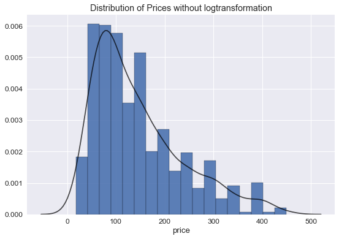

```python
from statlearning import plot_histogram

plot_histogram(df['price'])
plt.title('Distribution of Prices without logtransformation')
plt.savefig('price_hist.png')
plt.show()
```

**Dependent Variable Price after logtransformation**  
The house price is norammly distrubted after the logtransformation

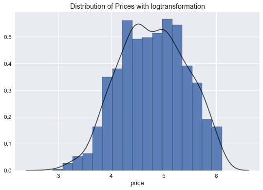

```python
plot_histogram(np.log(df['price']))
plt.title('Distribution of Prices with logtransformation')
plt.savefig('log_transformed_price_hist.png')
plt.show()
```

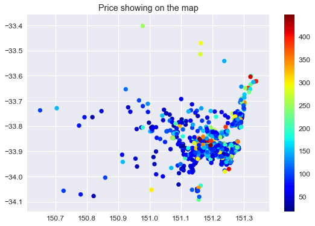

```python
## The price showing on 2D map showing the price is geographical related, eastern suburb showing higher price
fig1 = plt.gcf()
plt.scatter(df['longitude'],df['latitude'],c=round(df['price'],0),cmap='jet')
plt.colorbar()
plt.title("Price showing on the map")
fig1.savefig("Price_on_map.png")
```

#### Correlation between Dependent Variable Price and numerical Predictor Varialbe

In the model training and predicting stage we will only use log transfomred data so only plot log transformed price VS predictor value. Some strong correlation found for accommodates, bathrooms but not with reviews.

Correlation with log transformation

```python
# run this to get the updated info
# df_train_treated.info()
```

```python
# ### get list of predictor  variables  types , numerical and  categorical, boolean treated as categorical, these will be used for later exploratory data analysis

numerical_var=list(df_train_treated.select_dtypes(exclude=["object","uint8","bool"]).columns.values)
categorical_var = list(df_train_treated.select_dtypes(["object","uint8","bool"]).columns.values)
```

```python
# selecting all numerical var exclude price
# df_train_treated[numerical_var].loc[:,df_train_treated[numerical_var].columns != 'price'].
```

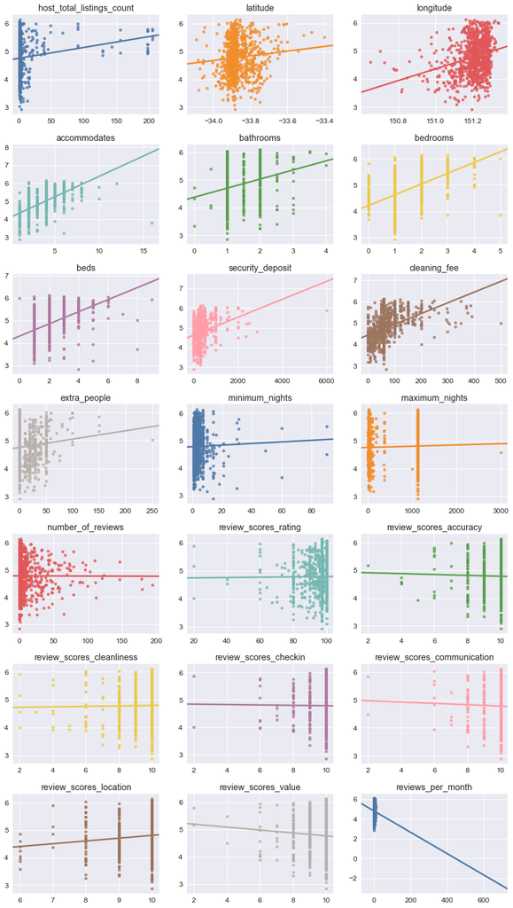

```python
from statlearning import plot_regressions

with sns.color_palette(crayon):
#     plot_regressions(X_train[numerical_var], np.log(Y_train))
    plot_regressions(df_train_treated[numerical_var].loc[:,df_train_treated[numerical_var].columns != 'price'], np.log(y))

    plt.show()
```

##### Visualisation of the Categorical Data

There are a few categorical data showing correlation with the price

```python
### Plot box plot function
def plot_boxplot(X, y):

    labels = list(X.columns)

    N, p = X.shape

    rows = int(np.ceil(p/3))

    fig, axes = plt.subplots(rows, 3, figsize=(12, rows*(12/4)))

    for i, ax in enumerate(fig.axes):
        if i < p:
            sns.boxplot(X.iloc[:,i], y, ax=ax)
            ax.set_xlabel('')
            ax.set_ylabel('')
            ax.set_title(labels[i])
        else:
            fig.delaxes(ax)

    sns.despine()
    plt.tight_layout()

    return fig, axes
```

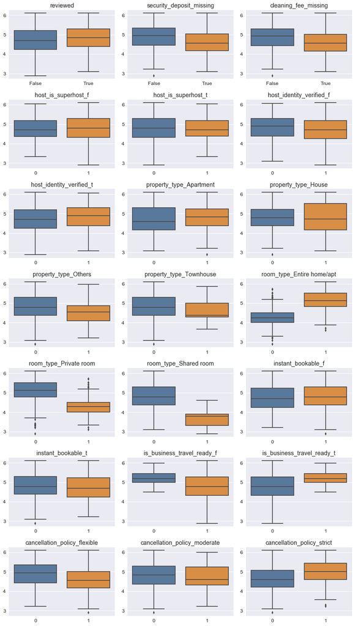

```python
with sns.color_palette(crayon):
    plot_boxplot(df_train_treated[categorical_var], np.log(y))

    plt.show()
```

```python
### Some details information of property_type
df['property_type'].value_counts()
```

```
Apartment    651
House        254
Others        63
Townhouse     32
Name: property_type, dtype: int64
```

Correlation heatmap shows top correlated numerical features with price

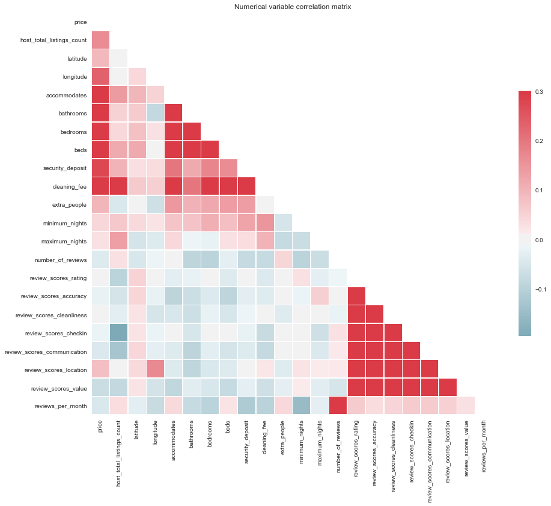

```python
#plot heatamp to show what factor most correlated with the price
# The most correlated features with price is Rooms, Bedroom2 and Bathrrom)
sns.set(style="white")
fig, ax = plt.subplots(figsize=(9,9))
# Compute the correlation matrix
corr = df_train_treated[numerical_var].corr()
# Generate a mask for the upper triangle
mask = np.zeros_like(corr, dtype=np.bool)
mask[np.triu_indices_from(mask)] = True
# Generate a custom diverging colormap
cmap = sns.diverging_palette(220, 10, as_cmap=True)
# Draw the heatmap with the mask and correct aspect ratio
sns.heatmap(corr, mask=mask, cmap=cmap, vmax=.3, center=0,
            square=True, linewidths=.5, cbar_kws={"shrink": .5},annot=False)
ax.set_title("Numerical variable correlation matrix")

fig.set_size_inches(15, 15)
fig.savefig("correlation_heatmap.png")
```

### Rescale variables

After rescaling the dataframe having scaled predictors

It is essential to scale the predictors before fitting regularised linear methods. Like several other machine learning algorithms, regularised linear methods do not perform well when predictors have very different scales (because the penalty term in the objective function treats all coefficients as comparable).

only scaling the continuous variables, so boolen and unit8 variable no need to apply StandardScaler

```python
df_train_treated.head(3)
```

| Id | price | host_total_listings_count | latitude | longitude | accommodates | bathrooms | bedrooms | beds | security_deposit | cleaning_fee | ... | room_type_Entire home/apt | room_type_Private room | room_type_Shared room | instant_bookable_f | instant_bookable_t | is_business_travel_ready_f | is_business_travel_ready_t | cancellation_policy_flexible | cancellation_policy_moderate | cancellation_policy_strict |
| --- | --- | --- | --- | --- | --- | --- | --- | --- | --- | --- | --- | --- | --- | --- | --- | --- | --- | --- | --- | --- | --- |
| 0 | 150 | 22.0 | -33.846469 | 151.205171 | 2 | 1.0 | 1 | 1.0 | 500.000000 | 330.000000 | ... | 1 | 0 | 0 | 1 | 0 | 1 | 0 | 0 | 0 | 1 |
| 1 | 66 | 1.0 | -33.895736 | 151.173529 | 2 | 1.5 | 1 | 1.0 | 395.393728 | 75.176046 | ... | 0 | 1 | 0 | 1 | 0 | 1 | 0 | 1 | 0 | 0 |
| 2 | 325 | 1.0 | -33.879322 | 151.222408 | 4 | 2.0 | 2 | 2.0 | 500.000000 | 180.000000 | ... | 1 | 0 | 0 | 1 | 0 | 1 | 0 | 0 | 1 | 0 |

3 rows × 43 columns

```python
##### function to rescale varialbes apply to both training and testing data
# After the function applied dataframe all continuous varibales rescaled
# 1. get the list of features to be rescaled
# 2. using MinMaxScaler rescale these features
# 3. The dataframe is updated
#
######

def rescale_df(dataframe, SCALER= StandardScaler()):
    # get list of features to be rescaled
    features_with_continuous_var = []
    for column in dataframe.columns:
        if (column != 'price' and  #exclude the resonpse variable
            (dataframe[column].dtype == np.float64 or
             dataframe[column].dtype == np.int64)):   #check datatype
            features_with_continuous_var.append(column)

    ### rescale dataframe

    scaler = SCALER
    dataframe.loc[:,features_with_continuous_var] = scaler.fit_transform(dataframe.loc[:,features_with_continuous_var])
    return dataframe
```

```python
df_train_treated.head(3)
```

| Id | price | host_total_listings_count | latitude | longitude | accommodates | bathrooms | bedrooms | beds | security_deposit | cleaning_fee | ... | room_type_Entire home/apt | room_type_Private room | room_type_Shared room | instant_bookable_f | instant_bookable_t | is_business_travel_ready_f | is_business_travel_ready_t | cancellation_policy_flexible | cancellation_policy_moderate | cancellation_policy_strict |
| --- | --- | --- | --- | --- | --- | --- | --- | --- | --- | --- | --- | --- | --- | --- | --- | --- | --- | --- | --- | --- | --- |
| 0 | 150 | 22.0 | -33.846469 | 151.205171 | 2 | 1.0 | 1 | 1.0 | 500.000000 | 330.000000 | ... | 1 | 0 | 0 | 1 | 0 | 1 | 0 | 0 | 0 | 1 |
| 1 | 66 | 1.0 | -33.895736 | 151.173529 | 2 | 1.5 | 1 | 1.0 | 395.393728 | 75.176046 | ... | 0 | 1 | 0 | 1 | 0 | 1 | 0 | 1 | 0 | 0 |
| 2 | 325 | 1.0 | -33.879322 | 151.222408 | 4 | 2.0 | 2 | 2.0 | 500.000000 | 180.000000 | ... | 1 | 0 | 0 | 1 | 0 | 1 | 0 | 0 | 1 | 0 |

3 rows × 43 columns

```python
df_train_rescaled=rescale_df(df_train_treated)
```

```python
df_test_rescaled = rescale_df(df_test_treated)
```

```python
df_train_rescaled.head(3)
```

| Id | price | host_total_listings_count | latitude | longitude | accommodates | bathrooms | bedrooms | beds | security_deposit | cleaning_fee | ... | room_type_Entire home/apt | room_type_Private room | room_type_Shared room | instant_bookable_f | instant_bookable_t | is_business_travel_ready_f | is_business_travel_ready_t | cancellation_policy_flexible | cancellation_policy_moderate | cancellation_policy_strict |
| --- | --- | --- | --- | --- | --- | --- | --- | --- | --- | --- | --- | --- | --- | --- | --- | --- | --- | --- | --- | --- | --- |
| 0 | 150 | 0.549979 | 0.298456 | -0.005907 | -0.587736 | -0.524032 | -0.509428 | -0.667909 | 2.965035e-01 | 4.551432 | ... | 1 | 0 | 0 | 1 | 0 | 1 | 0 | 0 | 0 | 1 |
| 1 | 66 | -0.222261 | -0.425750 | -0.397813 | -0.587736 | 0.502412 | -0.509428 | -0.667909 | 3.222421e-16 | 0.000000 | ... | 0 | 1 | 0 | 1 | 0 | 1 | 0 | 1 | 0 | 0 |
| 2 | 325 | -0.222261 | -0.184470 | 0.207591 | 0.602012 | 1.528855 | 0.745321 | 0.224425 | 2.965035e-01 | 1.872269 | ... | 1 | 0 | 0 | 1 | 0 | 1 | 0 | 0 | 1 | 0 |

3 rows × 43 columns

# Model training

### Train test split

train test split is required to have a test set evalute our model performance

```python
df_train_rescaled.shape
```

```
(1000, 43)
```

```python
# np.log(df_train_rescaled[response])
# df_train_rescaled[predictors]
```

```python
X.shape
```

```
(1000, 28)
```

```python
from sklearn.model_selection import train_test_split

response='price'
predictors=list(df_train_rescaled.columns.values[1:])

# Randomly split indexes
index_train, index_test  = train_test_split(np.array(df_train_rescaled.index), train_size=0.9, random_state=666)

# Write training and test sets
train = df_train_rescaled.loc[index_train,:].copy()
test =  df_train_rescaled.loc[index_test,:].copy()

# y_train = train[response]
# y_test = test[response]

# with log transformation

y_train = np.log(train[response])
y_test = np.log(test[response])


X_train = train[predictors].copy()
X_test = test[predictors].copy()
```

### XGB train test split

```python
from sklearn.model_selection import train_test_split

# response='price'
# predictors=list(df_train_rescaled.columns.values[1:])

# X_with_dummy
# y

# Randomly split indexes
index_train, index_test  = train_test_split(np.array(X_with_dummy.index), train_size=0.9, random_state=666)

# # Write training and test sets
X_train_xgb = X_with_dummy.loc[index_train,:].copy()
X_test_xgb =   X_with_dummy.loc[index_test,:].copy()

# # with log transformation
y_train_xgb =np.log(y[index_train].copy())
y_test_xgb =np.log(y[index_test].copy())



# # with log transformation

# y_train = np.log(train[response])
# y_test = np.log(test[response])


# X_train = train[predictors].copy()
# X_test = test[predictors].copy()
```

```python
X_test_xgb.shape
```

```
(100, 39)
```

```python
# y[index_train].copy
```

```python
rain = df_train_rescaled.loc[index_train,:].copy()
```

##### training on full model

```python
## This wil be used to fit the final model before predicting to have more samples
response='price'
predictors=list(df_train_rescaled.columns.values[1:])
X_train_full=df_train_rescaled[predictors].copy()
y_train_full=np.log(df_train_rescaled[response])
```

[output not shown]

```python
y_train.shape
```

```
(900,)
```

### OLS Model

```python
from sklearn.linear_model import LinearRegression

ols = LinearRegression()
# ols.fit(X_train, y_train)
ols.fit(X_train_full, y_train_full)
```

```
LinearRegression(copy_X=True, fit_intercept=True, n_jobs=1, normalize=False)
```

### Subset Selection Model

```python
%%time
from statlearning import forward
fwd = forward()
# fwd.fit(X_train, y_train)
fwd.fit(X_train_full, y_train_full)
```

```
Wall time: 3.47 s
```

### Ridge regression Model

```python
%%time

from sklearn.pipeline import Pipeline
alphas = list(np.logspace(-25, 15, 300, base=2))

ridge = Pipeline([

    ('estimator', RidgeCV(alphas=alphas, cv=10)),
])

# ridge.fit(X_train, y_train)
ridge.fit(X_train_full, y_train_full)
```

```
Wall time: 20.2 s
```

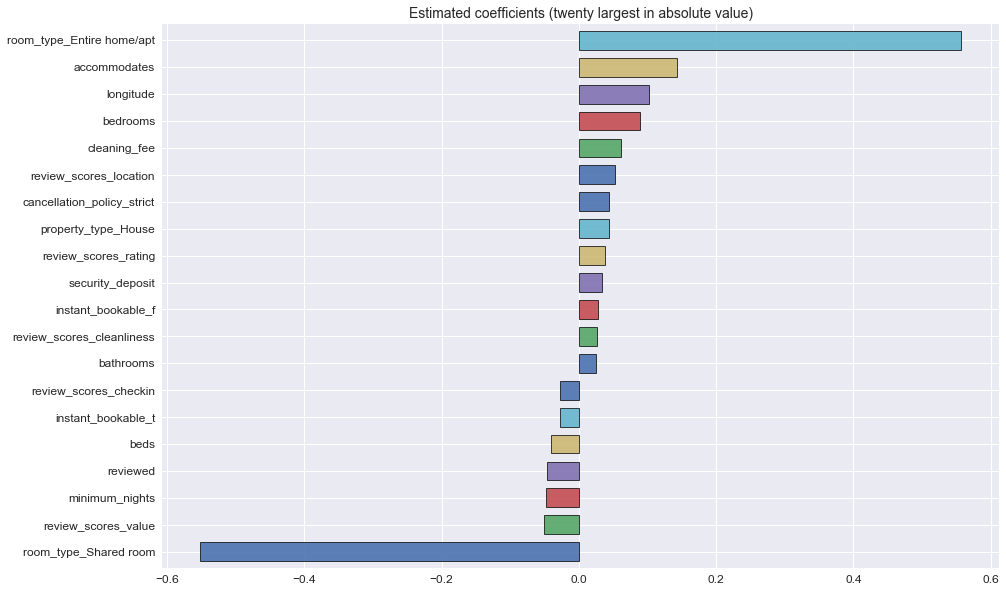

```python
from statlearning import plot_coefficients


plot_coefficients(ridge._final_estimator, predictors)
figure = plt.gcf() # get current figure
figure.set_size_inches(15, 10)
figure.savefig("Estimated_Coefficient_ridge.png")
```

### Lasso Model

```python
%%time
from sklearn.linear_model import LassoCV
lasso = Pipeline([
        ('estimator', LassoCV(alphas=alphas,cv=10,max_iter=10000)),
])

# lasso.fit(X_train, y_train)
lasso.fit(X_train_full, y_train_full)
```

```
Wall time: 469 ms
```

```python
reg = lasso._final_estimator # the final estimator attribute refers to the pipeline
np.sum(reg.coef_==0.0)
```

```
16
```

```python
reg
```

```
LassoCV(alphas=[2.9802322387695313e-08, 3.2698036909585666e-08, 3.5875110799487754e-08, 3.9360882074795934e-08, 4.3185345025557644e-08, 4.738140830869909e-08, 5.1985178119731008e-08, 5.7036268878567767e-08, 6.2578144102838812e-08, 6.8658490401835774e-08, 7.5329627809226066e-08, 8.2648959985359884e-0…
    copy_X=True, cv=10, eps=0.001, fit_intercept=True, max_iter=10000,
    n_alphas=100, n_jobs=1, normalize=False, positive=False,
    precompute='auto', random_state=None, selection='cyclic', tol=0.0001,
    verbose=False)
```

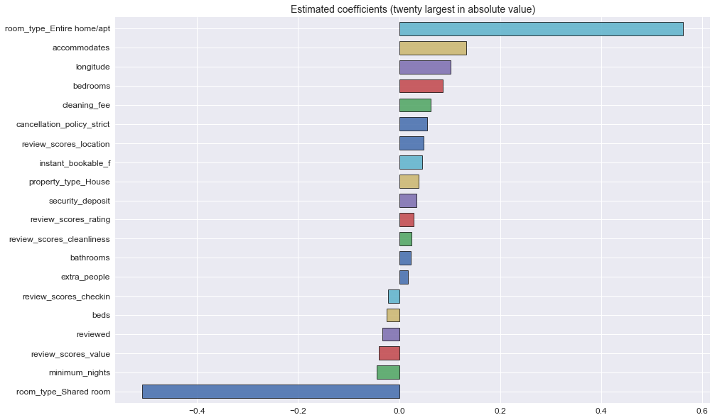

```python
from statlearning import plot_coefficients

plot_coefficients(reg, predictors)
figure = plt.gcf() # get current figure
figure.set_size_inches(15, 10)
figure.savefig("Lasso_Coefficient_ridge.png")
```

### Elastic Net Model

```python
from sklearn.linear_model import ElasticNetCV

enet = ElasticNetCV(l1_ratio=[0.01,0.1,0.2,0.3,0.4,0.5,0.6,0.7,0.8,0.9, 0.99], cv=10)
# enet.fit(X_train, y_train)
enet.fit(X_train_full, y_train_full)
```

```
ElasticNetCV(alphas=None, copy_X=True, cv=10, eps=0.001, fit_intercept=True,
       l1_ratio=[0.01, 0.1, 0.2, 0.3, 0.4, 0.5, 0.6, 0.7, 0.8, 0.9, 0.99],
       max_iter=1000, n_alphas=100, n_jobs=1, normalize=False,
       positive=False, precompute='auto', random_state=None,
       selection='cyclic', tol=0.0001, verbose=0)
```

```python
enet.l1_ratio_
```

```
0.98999999999999999
```

```python
enet = Pipeline([
       ('estimator', ElasticNetCV(l1_ratio=[0.01,0.1,0.2,0.3,0.4,0.5,0.6,0.7,0.8,0.9, 0.99], cv=5, n_alphas=200,max_iter=10000)),
])

# enet.fit(X_train, y_train)
enet.fit(X_train_full, y_train_full)
```

```
Pipeline(memory=None,
     steps=[('estimator', ElasticNetCV(alphas=None, copy_X=True, cv=5, eps=0.001, fit_intercept=True,
       l1_ratio=[0.01, 0.1, 0.2, 0.3, 0.4, 0.5, 0.6, 0.7, 0.8, 0.9, 0.99],
       max_iter=10000, n_alphas=200, n_jobs=1, normalize=False,
       positive=False, precompute='auto', random_state=None,
       selection='cyclic', tol=0.0001, verbose=0))])
```

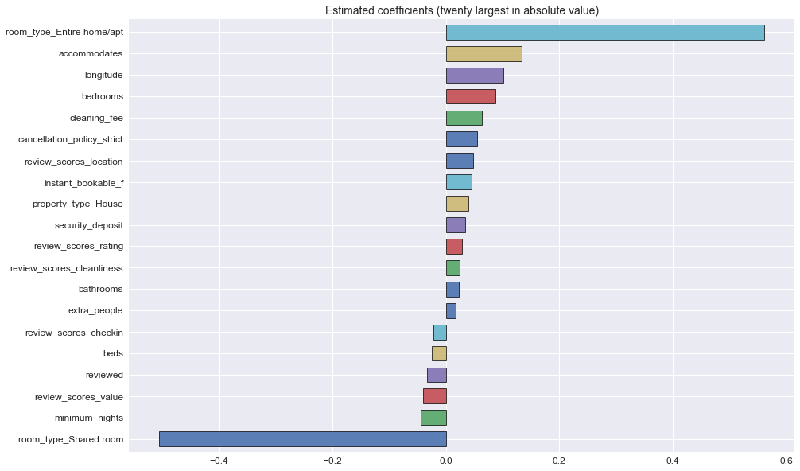

```python
plot_coefficients(enet._final_estimator, predictors)
figure = plt.gcf() # get current figure
figure.set_size_inches(15, 10)
figure.savefig("ElasticNet_Coefficient_ridge.png")
```

### KNN Model

```python
from sklearn.neighbors import KNeighborsRegressor
```

```python
from sklearn.model_selection import GridSearchCV

knn_model = KNeighborsRegressor()

tuning_parameters = {
    'n_neighbors': np.arange(1,51),
}

knn_search =  GridSearchCV(knn_model, tuning_parameters, cv=5,  scoring = 'neg_mean_squared_error',
                           return_train_score=False, n_jobs=4)
knn_search.fit(X_train, y_train)
```

```
GridSearchCV(cv=5, error_score='raise',
       estimator=KNeighborsRegressor(algorithm='auto', leaf_size=30, metric='minkowski',
          metric_params=None, n_jobs=1, n_neighbors=5, p=2,
          weights='uniform'),
       fit_params=None, iid=True, n_jobs=4,
       param_grid={'n_neighbors': array([ 1,  2,  3,  4,  5,  6,  7,  8,  9, 10, 11, 12, 13, 14, 15, 16, 17,
       18, 19, 20, 21, 22, 23, 24, 25, 26, 27, 28, 29, 30, 31, 32, 33, 34,
       35, 36, 37, 38, 39, 40, 41, 42, 43, 44, 45, 46, 47, 48, 49, 50])},
       pre_dispatch='2*n_jobs', refit=True, return_train_score=False,
       scoring='neg_mean_squared_error', verbose=0)
```

```python
knn = KNeighborsRegressor(n_neighbors=15)

from sklearn.model_selection import cross_val_score
scores = cross_val_score(knn, X_train, y_train, cv=5, scoring = 'neg_mean_squared_error')
scores
```

```
array([-0.19673104, -0.18207289, -0.19090434, -0.16688249, -0.2331754 ])
```

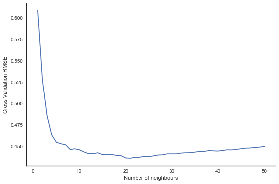

```
Lowest CV error: K = 21
```

```python
neighbours=np.arange(1, 51)

cv_rmse = []
for k in neighbours:
    model = KNeighborsRegressor(n_neighbors= k)
    scores = cross_val_score(model, X_train, y_train, cv=5, scoring = 'neg_mean_squared_error')
    rmse = np.sqrt(-1*np.mean(scores))
    cv_rmse.append(rmse)

fig, ax= plt.subplots()
ax.plot(neighbours, cv_rmse)
ax.set_xlabel('Number of neighbours')
ax.set_ylabel('Cross Validation RMSE')
sns.despine()
plt.show()

print(f'Lowest CV error: K = {1 + np.argmin(cv_rmse)}')
```

```python
knn = KNeighborsRegressor(n_neighbors=20)
knn.fit(X_train, y_train)
# knn.fit(X_train_full, y_train_full)
```

```
KNeighborsRegressor(algorithm='auto', leaf_size=30, metric='minkowski',
          metric_params=None, n_jobs=1, n_neighbors=20, p=2,
          weights='uniform')
```

### Random Forest

credit to https://towardsdatascience.com/hyperparameter-tuning-the-random-forest-in-python-using-scikit-learn-28d2aa77dd74

with hyper parameter tuning

```python
%%time
from sklearn.ensemble import RandomForestRegressor
model = RandomForestRegressor(n_estimators=500)

tuning_parameters = {
    'min_samples_leaf': [1,5, 10, 20, 50],
    'max_features': np.arange(1, X_train_full.shape[1], 5),
}

rf_search = RandomizedSearchCV(model, tuning_parameters, cv = 10, n_iter= 45, return_train_score=False, n_jobs=-1,
                              random_state = 20)
# rf_search.fit(X_train, y_train)
rf_search.fit(X_train_full, y_train_full)


rf = rf_search.best_estimator_

print('Best parameters found by randomised search:', rf_search.best_params_, '\n')
```

```
Best parameters found by randomised search: {'min_samples_leaf': 1, 'max_features': 31}

Wall time: 1min 56s
```

```python
# rf.n_estimators = 500
# rf.fit(X_train, y_train)
rf.fit(X_train_full, y_train_full)
```

```
RandomForestRegressor(bootstrap=True, criterion='mse', max_depth=None,
           max_features=31, max_leaf_nodes=None, min_impurity_decrease=0.0,
           min_impurity_split=None, min_samples_leaf=1,
           min_samples_split=2, min_weight_fraction_leaf=0.0,
           n_estimators=500, n_jobs=1, oob_score=False, random_state=None,
           verbose=0, warm_start=False)
```

Randomized search on hyper parametersRandomizedSearchCV implements a “fit” and a “score” method. It also implements “predict”, “predict_proba”, “decision_function”, “transform” and “inverse_transform” if they are implemented in the estimator used.

The parameters of the estimator used to apply these methods are optimized by cross-validated search over parameter settings.

In contrast to GridSearchCV, not all parameter values are tried out, but rather a fixed number of parameter settings is sampled from the specified distributions. The number of parameter settings that are tried is given by n_iter.

```python
feat_importances = pd.Series(rf.feature_importances_, index=X_train.columns)
feat_importances = feat_importances.nlargest(20)
feat_importances.plot(kind='barh')
plt.title("Top 20 Random Forest feature importance")
```

[output not shown]

```python
feat_importances
```

```
room_type_Entire home/apt     0.582318
accommodates                  0.078409
room_type_Private room        0.065302
longitude                     0.054000
bedrooms                      0.036076
latitude                      0.031652
cleaning_fee                  0.030487
bathrooms                     0.015652
room_type_Shared room         0.013312
beds                          0.012685
minimum_nights                0.010795
security_deposit              0.007943
cancellation_policy_strict    0.006922
reviews_per_month             0.006418
number_of_reviews             0.006398
review_scores_rating          0.006288
maximum_nights                0.005211
host_total_listings_count     0.004223
extra_people                  0.003874
review_scores_cleanliness     0.003129
dtype: float64
```

### XGB Model

```python
X_train_full.shape
y_train_full.shape
```

```
(1000,)
```

```python
X
```

| Id | host_is_superhost | host_total_listings_count | host_identity_verified | latitude | longitude | property_type | room_type | accommodates | bathrooms | bedrooms | ... | review_scores_accuracy | review_scores_cleanliness | review_scores_checkin | review_scores_communication | review_scores_location | review_scores_value | instant_bookable | is_business_travel_ready | cancellation_policy | reviews_per_month |
| --- | --- | --- | --- | --- | --- | --- | --- | --- | --- | --- | --- | --- | --- | --- | --- | --- | --- | --- | --- | --- | --- |
| 0 | f | 22.0 | t | -33.846469 | 151.205171 | Apartment | Entire home/apt | 2 | 1.0 | 1 | ... | 10.0 | 10.0 | 10.0 | 10.0 | 10.0 | 10.0 | f | f | strict | 0.53 |
| 1 | f | 1.0 | t | -33.895736 | 151.173529 | Apartment | Private room | 2 | 1.5 | 1 | ... | NaN | NaN | NaN | NaN | NaN | NaN | f | f | flexible | NaN |
| 2 | t | 1.0 | t | -33.879322 | 151.222408 | House | Entire home/apt | 4 | 2.0 | 2 | ... | 10.0 | 10.0 | 10.0 | 10.0 | 10.0 | 9.0 | f | f | moderate | 2.38 |

3 rows × 28 columns

```python
[i/10.0 for i in range(0,10,3)]
```

[output not shown]

```python
np.arange(3,7)
```

```
array([3, 4, 5, 6])
```

```python
%%time
### XGB from leture
### default parameters
#(max_depth=3, learning_rate=0.1, n_estimators=100,
# silent=True, objective='reg:linear', booster='gbtree',
# n_jobs=1, nthread=None, gamma=0, min_child_weight=1, max_delta_step=0,
# subsample=1, colsample_bytree=1, colsample_bylevel=1, reg_alpha=0, reg_lambda=1,
# scale_pos_weight=1, base_score=0.5, random_state=0, seed=None, missing=None, **kwargs)
##############################################
from sklearn.model_selection import GridSearchCV
model = xgb.XGBRegressor(random_state=166)

subsample = np.arange(0.5,1,0.2)
maxdepth = np.arange(1,20)

tuning_parameters = {
    'learning_rate': [0.005,0.01, 0.05],
    'n_estimators' : [250, 500, 750],
    'max_depth' : maxdepth,
    'subsample' : subsample,
    'reg_alpha' : [0,0.2,0.5], #default
    'reg_lambda' : [0.5,0.8,1],
}

# tuning_parameters = {'learning_rate': [0.01], 'max_depth': maxdepth, 'n_estimators': [750], 'reg_alpha': [0.2], 'reg_lambda': [0.8], 'subsample': [0.5],}



bst = RandomizedSearchCV(model, tuning_parameters, n_iter = 2000, cv = 10, return_train_score=False, n_jobs=-1)
# bst = GridSearchCV(model, tuning_parameters, cv = 10, return_train_score=False, n_jobs=-1)

# bst.fit(X_train, y_train)
# bst.fit(X_train_xgb, y_train_xgb)
# bst.fit(X_with_dummy,y)

bst.fit(X_train_full, y_train_full) # full training data without split

print('Best parameters found by randomised search:', bst.best_params_, '\n')
best_xgb_params=bst.best_params_
```

```
Best parameters found by randomised search: {'subsample': 0.5, 'reg_lambda': 1, 'reg_alpha': 0.2, 'n_estimators': 750, 'max_depth': 3, 'learning_rate': 0.01}

Wall time: 1h 59min 23s
```

### LGB

```python
%%time
### default
##class lightgbm.
##LGBMModel(boosting_type='gbdt', num_leaves=31, max_depth=-1,
##        learning_rate=0.1, n_estimators=100, subsample_for_bin=200000,
##            objective=None, class_weight=None, min_split_gain=0.0, min_child_weight=0.001,
##        min_child_samples=20, subsample=1.0, subsample_freq=0, colsample_bytree=1.0,
##   reg_alpha=0.0, reg_lambda=0.0, random_state=None, n_jobs=-1, silent=True, **kwargs



import lightgbm as lgb

numleaves = np.arange(2,40,2)
model = lgb.LGBMRegressor(objective='regression')

tuning_parameters = {
    'learning_rate': [0.005,0.01, 0.05, 0.1],
    'n_estimators' : [250, 500, 750, 1000, 1500],
    'max_depth' : [1,2, 3, 4],
    'subsample' : [0.6, 0.8, 1.0],
    'reg_alpha': [i/10.0 for i in range(0,11)],
    'reg_lambda':[i/10.0 for i in range(0,11)],
    'num_leaves': numleaves

}


lbst = RandomizedSearchCV(model, tuning_parameters, n_iter = 4000, cv = 10, return_train_score=False, n_jobs=-1)
# lbst.fit(X_train_xgb, y_train_xgb)
lbst.fit(X_train_full, y_train_full)

print('Best parameters found by randomised search:', lbst.best_params_, '\n')

best_lgb_params=lbst.best_params_
```

```
Best parameters found by randomised search: {'subsample': 0.8, 'reg_lambda': 0.4, 'reg_alpha': 0.9, 'num_leaves': 30, 'n_estimators': 500, 'max_depth': 2, 'learning_rate': 0.05}

Wall time: 49min 30s
```

### Bayesian Ridge

```python
len(list((np.logspace(-20, 10, 100, base=2))))
```

```
100
```

```python
alphas
```

[output not shown]

```python
# alphas = list(np.logspace(-20, 10, 100, base=2)) # this alphas chosen including the default
alphas = np.array([1,0.1,0.01,0.001,0.0001,0])
from sklearn.linear_model import BayesianRidge
model = BayesianRidge()
tuning_parameters = {
    'n_iter': [100, 300, 500],
    'alpha_1' : alphas,
    'alpha_2' : alphas,
    'lambda_1' : alphas,
    'lambda_2' : alphas,
}


BayesRidge = RandomizedSearchCV(model, tuning_parameters, n_iter =1000, cv = 10, return_train_score=False, n_jobs=-1)
# BayesRidge.fit(X_train, y_train)
BayesRidge.fit(X_train_full, y_train_full)

print('Best parameters found by randomised search:', BayesRidge.best_params_, '\n')

BayesRidge_params=BayesRidge.best_params_
```

```
Best parameters found by randomised search: {'n_iter': 500, 'lambda_2': 1.0, 'lambda_1': 1.0, 'alpha_2': 1.0, 'alpha_1': 0.0}
```

### Linear SVC

```python
from sklearn import svm
model = svm.SVR()
tuning_parameters = {
    'kernel': ['rbf','linear'],

    'C' : [0.05,0.1,0.5,1.0],
    'degree': [1,2,3,4],
    'epsilon' : [0.05,0.1,0.2,0.5]

}
svc = RandomizedSearchCV(model, tuning_parameters, n_iter =60, cv = 10, return_train_score=False, n_jobs=-1)
svc.fit(X_train, y_train)
print('Best parameters found by randomised search:', svc.best_params_, '\n')

svc_params=svc.best_params_
```

```
Best parameters found by randomised search: {'kernel': 'linear', 'epsilon': 0.1, 'degree': 4, 'C': 0.1}
```

### Stacked regression

```python
%%time
from mlxtend.regressor import StackingRegressor
from mlxtend.regressor import StackingCVRegressor
from sklearn.svm import SVR
from sklearn.linear_model import LinearRegression

# model_gb=GradientBoostingRegressor()

model_xgb = xgb.XGBRegressor()

model_lgb = lgb.LGBMRegressor(objective='regression')


# model_gb = model_gb.set_params(**best_gb_params)
model_xgb = model_xgb.set_params(**best_xgb_params)
model_lgb = model_lgb.set_params(**best_lgb_params)
# fwd, lasso, best_model_xgb,best_rf_iter_1000

#my way
# stregr = StackingRegressor(regressors=[model_gb, model_xgb, model_lgb],
#                            meta_regressor=svr_rbf)

# models = [model_gb,model_xgb,model_lgb]
# models = [ols,  ridge, lasso, enet,model_gb,model_xgb,model_lgb,rf,knn,BayesRidge]
# models = [model_lgb,model_xgb,BayesRidge,rf,lasso,ridge,enet]
models = [model_lgb,model_xgb,rf,lasso]


# lecture way
stack = StackingCVRegressor(models, meta_regressor = LinearRegression(), cv=10)
stack.fit(X_train_full.values,y_train_full.ravel())
# Training the stacking classifier

# stregr.fit(X_train_full, y_train_full)
# stregr.predict(X_test)


# Evaluate and visualize the fit

# print("Mean Squared Error: %.4f"
#       % np.sqrt(np.mean((np.exp(stregr.predict(X_test))-np.exp(y_test))**2)))
# print('Variance Score: %.4f' % stregr.score(X_test, y_test))


#Wall time: 2min 56s
#Wall time: 3min 20s full training data
```

```
Wall time: 46.7 s
```

```python
# X_train_full.shape
```

[output not shown]

### XGB only evaluation

```python
columns=['Test RMSE', 'Test R2']
rows=["XGB",'LGB',"stack"]
results=pd.DataFrame(0.0, columns=columns, index=rows)

# methods=[bst,lbst,stack]
methods=[bst]
for i, method in enumerate(methods):
#     if method == stack:
#         y_pred=method.predict(X_test_xgb.values)
#     else:
    y_pred = method.predict(X_test_xgb)
    results.iloc[i,0] = np.sqrt(mean_squared_error(np.exp(y_test_xgb), np.exp(y_pred)))
#     results.iloc[i,0] = np.sqrt(mean_squared_error(y_test_xgb, y_pred))
    results.iloc[i,1] = r2_score(np.exp(y_test_xgb), np.exp(y_pred))
#     results.iloc[i,1] = r2_score(y_test_xgb, y_pred)

results.sort_values(['Test RMSE']).round(3)
```

|  | Test RMSE | Test R2 |
| --- | --- | --- |
| LGB | 0.000 | 0.000 |
| stack | 0.000 | 0.000 |
| XGB | 52.019 | 0.587 |

# Model evaluation

Result shows XGB is the best model and knn is worst

```python
columns=['Test RMSE', 'Test R2']
rows=['OLS', 'Forward', 'Ridge', 'Lasso', 'Elastic Net', 'knn', "SVC","radom forest","lightGBM","XGB","gradient boost","BayesRidge","stack"]
results=pd.DataFrame(0.0, columns=columns, index=rows)

methods=[ols, fwd, ridge, lasso, enet,knn,svc,rf,lbst,bst,gb,BayesRidge,stack]

for i, method in enumerate(methods):
    if method == stack:
        y_pred=method.predict(X_test.values)
    else:
        y_pred = method.predict(X_test)
    results.iloc[i,0] = np.sqrt(mean_squared_error(np.exp(y_test), np.exp(y_pred)))
    results.iloc[i,1] = r2_score(np.exp(y_test), np.exp(y_pred))

results.sort_values(['Test RMSE']).round(3)
```

|  | Test RMSE | Test R2 |
| --- | --- | --- |
| XGB | 52.101 | 0.586 |
| stack | 52.356 | 0.582 |
| gradient boost | 53.150 | 0.569 |
| lightGBM | 54.637 | 0.544 |
| Forward | 55.270 | 0.534 |
| Lasso | 55.963 | 0.522 |
| Elastic Net | 56.005 | 0.521 |
| Ridge | 56.117 | 0.519 |
| OLS | 56.118 | 0.519 |
| BayesRidge | 56.120 | 0.519 |
| radom forest | 56.460 | 0.513 |
| SVC | 56.977 | 0.504 |
| knn | 62.354 | 0.407 |

# Prediction on testing data and output result

```python
%%time
### Refit the model to full training data set
# lbst.fit(X_train_full, y_train_full)
# bst.fit(X_train_full, y_train_full)
# gb.fit(X_train_full,y_train_full)
```

```
Wall time: 0 ns
```

```python
# predict with light gbm
### Train full training data set using learnt light gbm
X_test_final = df_test_rescaled
y_pred_final = lbst.predict(X_test_final)
y_pred_no_transform_final= np.exp(y_pred_final)
prediction_results=pd.DataFrame(y_pred_no_transform_final,columns=['price'])
prediction_results.to_csv("lightgbm.prediction_full.csv",index_label="Id")
```

#### XGB prediction on simple way only create dummy variables

[output not shown]

```python
## get the X and y for training data

y_pred_final = bst.predict(X_test_with_dummy)
# y_pred_no_transform_final = np.exp(y_pred_final)
y_pred_no_transform_final = y_pred_final
prediction_results=pd.DataFrame(y_pred_no_transform_final,columns=['price'])
prediction_results.to_csv("XGB_prediction_full.csv",index_label='Id')
```

```python
### Train full training data set using learnt XGB model

## get the X and y for training data
X_test_final = df_test_rescaled
y_pred_final = lbst.predict(X_test_final)
y_pred_no_transform_final = np.exp(y_pred_final)
prediction_results=pd.DataFrame(y_pred_no_transform_final,columns=['price'])
prediction_results.to_csv("XGB_prediction_full.csv",index_label='Id')
```

#### Gradient Boost prediction

```python
### Train full training data set using learnt XGB model
## get the X and y for training data
X_test_final = df_test_rescaled
y_pred_final = gb.predict(X_test_final)
y_pred_no_transform_final = np.exp(y_pred_final)
prediction_results=pd.DataFrame(y_pred_no_transform_final,columns=['price'])
prediction_results.to_csv("GradientBoost_prediction_full.csv",index_label='Id')
```

#### stack regression prediction

```python
## output result for stacked regression
X_test_final = df_test_rescaled
# y_pred_final=stregr.predict(X_test_final)
y_pred_final=stack.predict(X_test_final.values)

y_pred_no_transform_final = np.exp(y_pred_final)
prediction_results=pd.DataFrame(y_pred_no_transform_final,columns=['price'])
prediction_results.to_csv("stack_prediction_full.csv",index_label='Id')
```

```python
## output result for stacked regression
X_test_final = df_test_rescaled
# y_pred_final=stregr.predict(X_test_final)
y_pred_final=ols.predict(X_test_final.values)

y_pred_no_transform_final = np.exp(y_pred_final)
prediction_results=pd.DataFrame(y_pred_no_transform_final,columns=['price'])
prediction_results.to_csv("ols_full.csv",index_label='Id')
```

```python
## output result for stacked regression
X_test_final = df_test_rescaled
# y_pred_final=stregr.predict(X_test_final)
y_pred_final=lasso.predict(X_test_final.values)

y_pred_no_transform_final = np.exp(y_pred_final)
prediction_results=pd.DataFrame(y_pred_no_transform_final,columns=['price'])
prediction_results.to_csv("lasso_full.csv",index_label='Id')
```

```python
## output result for bayesridge regression
X_test_final = df_test_rescaled
# y_pred_final=stregr.predict(X_test_final)
y_pred_final=BayesRidge.predict(X_test_final.values)

y_pred_no_transform_final = np.exp(y_pred_final)
prediction_results=pd.DataFrame(y_pred_no_transform_final,columns=['price'])
prediction_results.to_csv("BayesRidge_full.csv",index_label='Id')
```

```python
## output result for bayesridge regression
X_test_final = df_test_rescaled
# y_pred_final=stregr.predict(X_test_final)
y_pred_final=rf.predict(X_test_final.values)

y_pred_no_transform_final = np.exp(y_pred_final)
prediction_results=pd.DataFrame(y_pred_no_transform_final,columns=['price'])
prediction_results.to_csv("rf_full.csv",index_label='Id')
```

```python
## output result for bayesridge regression
X_test_final = df_test_rescaled
# y_pred_final=stregr.predict(X_test_final)
y_pred_final=ridge.predict(X_test_final.values)

y_pred_no_transform_final = np.exp(y_pred_final)
prediction_results=pd.DataFrame(y_pred_no_transform_final,columns=['price'])
prediction_results.to_csv("ridge_full.csv",index_label='Id')
```

```python
## output result for bayesridge regression
X_test_final = df_test_rescaled
# y_pred_final=stregr.predict(X_test_final)
y_pred_final=enet.predict(X_test_final.values)

y_pred_no_transform_final = np.exp(y_pred_final)
prediction_results=pd.DataFrame(y_pred_no_transform_final,columns=['price'])
prediction_results.to_csv("enet_full.csv",index_label='Id')
```

#### Average prediction result

```python
# #### ensemble result only select Elastic Net as they are similar
# columns=['Test RMSE', 'Test R2']
# # rows=['OLS', 'Forward', 'Ridge', 'Lasso', 'Elastic Net', "xgb",'knn']
# # rows=['Forward', 'Elastic Net', "xgb","best_rf_iter_1000"]
# results=pd.DataFrame(0.0, columns=columns, index=rows)

methods=[ols,  ridge, lasso, enet,lbst,bst,gb,rf,knn,stack]

accumulate_result = 0

for i, method in enumerate(methods):
    if method == stack:
        y_pred=method.predict(X_test.values)
    else:
        y_pred = method.predict(X_test_final)
        y_pred_no_transform = np.exp(y_pred)
    accumulate_result += y_pred_no_transform


ensemble_result=(accumulate_result/len(methods))




### Output average result
prediction_results=pd.DataFrame(ensemble_result,columns=['price'])
prediction_results.to_csv("average_prediction_result.csv",index_label='Id')
```